**Part 3 - Data Analysis**

The following SQL query was used to join the four source tables on the composite key (city, month_booking, landlord_type, listing_type) and filter for Madrid:

```
SELECT
    d.city,
    d.month_booking,
    d.landlord_type,
    d.listing_type,
    d.visitors,
    d.searchers,
    d.applicants,
    o.bookings,
    o.revenue_eur,
    m.commission_rate_pct,
    m.booking_fee_eur,
    m.avg_revenue_per_booking_eur,
    m.avg_rent_eur,
    s.available_listings,
    s.created_listings
FROM data_demand d
LEFT JOIN data_key_outcomes o
    ON d.city = o.city
    AND d.month_booking = o.month_booking
    AND d.landlord_type = o.landlord_type
    AND d.listing_type = o.listing_type
LEFT JOIN data_monetisation m
    ON d.city = m.city
    AND d.month_booking = m.month_booking
    AND d.landlord_type = m.landlord_type
    AND d.listing_type = m.listing_type
LEFT JOIN data_supply s
    ON d.city = s.city
    AND d.month_booking = s.month_booking
    AND d.landlord_type = s.landlord_type
    AND d.listing_type = s.listing_type
WHERE d.city = 'Madrid'
```

The output was exported to Excel and loaded into this notebook for analysis.

```python
import pandas as pd
df = pd.read_excel(r"C:\Users\pandi\Documents\Python Scripts\HousingAnywhere\HousingAnywhere_Madrid_Data.xlsx")

df.head()
```

|  | city | month_booking | landlord_type | listing_type | visitors | searchers | applicants | bookings | revenue_eur | commission_rate_pct | booking_fee_eur | avg_revenue_per_booking_eur | avg_rent_eur | available_listings | created_listings |
| --- | --- | --- | --- | --- | --- | --- | --- | --- | --- | --- | --- | --- | --- | --- | --- |
| 0 | Madrid | 2023-01-01 | PBSA | Room | 1365 | 448 | 119 | 42 | 5270 | 12 | 45 | 123 | 649 | 62 | 5 |
| 1 | Madrid | 2023-02-01 | PBSA | Room | 1472 | 484 | 124 | 39 | 4762 | 12 | 45 | 123 | 650 | 65 | 5 |
| 2 | Madrid | 2023-03-01 | PBSA | Room | 1310 | 532 | 134 | 41 | 4906 | 12 | 45 | 118 | 610 | 64 | 6 |
| 3 | Madrid | 2023-04-01 | PBSA | Room | 1381 | 500 | 132 | 43 | 5117 | 12 | 45 | 121 | 636 | 66 | 6 |
| 4 | Madrid | 2023-05-01 | PBSA | Room | 1378 | 490 | 126 | 39 | 4848 | 12 | 45 | 128 | 690 | 69 | 7 |

```python
# Check the data loaded correctly
print("Shape:", df.shape)
print("\nColumns:", df.columns.tolist())
print("\nDate range:", df['month_booking'].min(), "to", df['month_booking'].max())
print("\nLandlord types:", df['landlord_type'].unique())
print("\nListing types:", df['listing_type'].unique())
print("\nNull values:\n", df.isnull().sum())
```

```
Shape: (324, 15)

Columns: ['city', 'month_booking', 'landlord_type', 'listing_type', 'visitors', 'searchers', 'applicants', 'bookings', 'revenue_eur', 'commission_rate_pct', 'booking_fee_eur', 'avg_revenue_per_booking_eur', 'avg_rent_eur', 'available_listings', 'created_listings']

Date range: 2023-01-01 00:00:00 to 2025-12-01 00:00:00

Landlord types: ['PBSA' 'Private Landlord' 'Property Manager']

Listing types: ['Room' 'Studio' 'Apartment']

Null values:
 city                           0
month_booking                  0
landlord_type                  0
listing_type                   0
visitors                       0
searchers                      0
applicants                     0
bookings                       0
revenue_eur                    0
commission_rate_pct            0
booking_fee_eur                0
avg_revenue_per_booking_eur    0
avg_rent_eur                   0
available_listings             0
created_listings               0
dtype: int64
```

```python
df['year'] = df['month_booking'].dt.year

annual = df.groupby('year').agg(
    total_visitors = ('visitors', 'sum'),
    total_searchers = ('searchers', 'sum'),
    total_applicants = ('applicants', 'sum'),
     total_bookings = ('bookings', 'sum'),
    total_revenue = ('revenue_eur', 'sum')
).reset_index()

print(annual)
```

```
   year  total_visitors  total_searchers  total_applicants  total_bookings  \
0  2023          593310           213554             47375           11085
1  2024          769134           271314             55903           12570
2  2025          936254           318194             60953           12970

   total_revenue
0        2259916
1        2774154
2        3086915
```

[figure not shown]

```python
import matplotlib.pyplot as plt
import numpy as np

fig, ax = plt.subplots(figsize=(12, 7))
fig.suptitle('Madrid: Visitor to Booking Funnel 2023–2025', fontsize=16, fontweight='bold')

years = annual['year'].astype(str)
x = np.arange(len(years))
width = 0.2

metrics = [
    ('total_visitors', 'Visitors (K)', '#4C9BE8'),
    ('total_searchers', 'Searchers (K)', '#2ECC71'),
    ('total_applicants', 'Applicants (K)', '#F39C12'),
    ('total_bookings', 'Bookings (K)', '#E74C3C')
]

bar_positions = {}

for i, (col, label, color) in enumerate(metrics):
    values = annual[col] / 1000
    positions = x + (i - 1.5) * width
    bars = ax.bar(positions, values, width, label=label, color=color, alpha=0.8)
    bar_positions[col] = (positions, values)


    for j, (pos, val) in enumerate(zip(positions, values)):
        ax.text(pos, val + 5,
                f'{val:.0f}K', ha='center', fontsize=8, color='gray')

# Add connecting arrows between bars of same category
for col, color in [(m[0], m[2]) for m in metrics]:
    positions, values = bar_positions[col]
    for j in range(1, len(years)):
        growth = ((values.iloc[j] - values.iloc[j-1]) / values.iloc[j-1]) * 100
        x_start = positions[j-1] + width/2
        x_end = positions[j] - width/2
        y_mid = max(values.iloc[j], values.iloc[j-1]) + 20

        ax.annotate('',
                    xy=(x_end, values.iloc[j] + 5),
                    xytext=(x_start, values.iloc[j-1] + 5),
                    arrowprops=dict(arrowstyle='->', color=color, lw=1.5))

        ax.text((x_start + x_end) / 2, y_mid,
                f'+{growth:.0f}%',
                ha='center', fontsize=8, fontweight='bold', color=color,
                bbox=dict(boxstyle='round,pad=0.2', facecolor='white', alpha=0.8))

ax.set_xticks(x)
ax.set_xticklabels(years)
ax.set_ylabel('Volume (thousands)')
ax.legend()
ax.grid(axis='y', alpha=0.3)

plt.tight_layout()
plt.savefig('slide1_funnel.png', dpi=150, bbox_inches='tight')
plt.show()
```

Madrid shows strong top-of-funnel growth between 2023 and 2025:

- Visitors grew **+58%** (593K → 936K)
- Searchers grew **+49%** (214K → 318K)

However, growth slows significantly at the bottom of the funnel:

- Applicants grew only **+29%** (47K → 61K)
- Bookings grew only **+17%** (11K → 13K)

**Key insight:** Madrid is successfully attracting more visitors YoY, but the platform is losing a big proportion of them before they complete a booking. The gap between visitor growth (+58%) and booking growth (+17%) suggests either:

- Supply is not keeping up with demand
- There is friction in the matching or application process
- Listings are not meeting tenant expectations

```python
# Check revenue vs bookings growth
print("Revenue growth 2023-2025:",
      round((annual['total_revenue'].iloc[-1] - annual['total_revenue'].iloc[0]) / annual['total_revenue'].iloc[0] * 100, 1), "%")

print("Booking growth 2023-2025:",
      round((annual['total_bookings'].iloc[-1] - annual['total_bookings'].iloc[0]) / annual['total_bookings'].iloc[0] * 100, 1), "%")

print("Revenue per booking 2023:", round(annual['total_revenue'].iloc[0] / annual['total_bookings'].iloc[0], 2))
print("Revenue per booking 2025:", round(annual['total_revenue'].iloc[-1] / annual['total_bookings'].iloc[-1], 2))
```

```
Revenue growth 2023-2025: 36.6 %
Booking growth 2023-2025: 17.0 %
Revenue per booking 2023: 203.87
Revenue per booking 2025: 238.0
```

```python
# Revenue by landlord type per year
landlord_revenue = df.groupby(['year', 'landlord_type']).agg(
    total_revenue=('revenue_eur', 'sum'),
    total_bookings=('bookings', 'sum')
).reset_index()

print(landlord_revenue)

# Revenue by listing type per year
listing_revenue = df.groupby(['year', 'listing_type']).agg(
    total_revenue=('revenue_eur', 'sum'),
    total_bookings=('bookings', 'sum')
).reset_index()

print(listing_revenue)
```

```
   year     landlord_type  total_revenue  total_bookings
0  2023              PBSA         114004             809
1  2023  Private Landlord        1438198            7179
2  2023  Property Manager         707714            3097
3  2024              PBSA         138829             922
4  2024  Private Landlord        1781736            8206
5  2024  Property Manager         853589            3442
6  2025              PBSA         148662             936
7  2025  Private Landlord        1963133            8366
8  2025  Property Manager         975120            3668
   year listing_type  total_revenue  total_bookings
0  2023    Apartment        1102207            3794
1  2023         Room         514637            3723
2  2023       Studio         643072            3568
3  2024    Apartment        1377552            4342
4  2024         Room         621302            4190
5  2024       Studio         775300            4038
6  2025    Apartment        1535416            4475
7  2025         Room         692305            4375
8  2025       Studio         859194            4120
```

```python
print("=== LANDLORD TYPE GROWTH ===")
for landlord in ['PBSA', 'Private Landlord', 'Property Manager']:
    data = landlord_revenue[landlord_revenue['landlord_type'] == landlord]
    rev_2023 = data[data['year']==2023]['total_revenue'].values[0]
    rev_2025 = data[data['year']==2025]['total_revenue'].values[0]
    growth = (rev_2025 - rev_2023) / rev_2023 * 100
    print(f"{landlord}: +{growth:.1f}%")

print("\n=== LISTING TYPE GROWTH ===")
for listing in ['Apartment', 'Room', 'Studio']:
    data = listing_revenue[listing_revenue['listing_type'] == listing]
    rev_2023 = data[data['year']==2023]['total_revenue'].values[0]
    rev_2025 = data[data['year']==2025]['total_revenue'].values[0]
    growth = (rev_2025 - rev_2023) / rev_2023 * 100
    print(f"{listing}: +{growth:.1f}%")
```

```
=== LANDLORD TYPE GROWTH ===
PBSA: +30.4%
Private Landlord: +36.5%
Property Manager: +37.8%

=== LISTING TYPE GROWTH ===
Apartment: +39.3%
Room: +34.5%
Studio: +33.6%
```

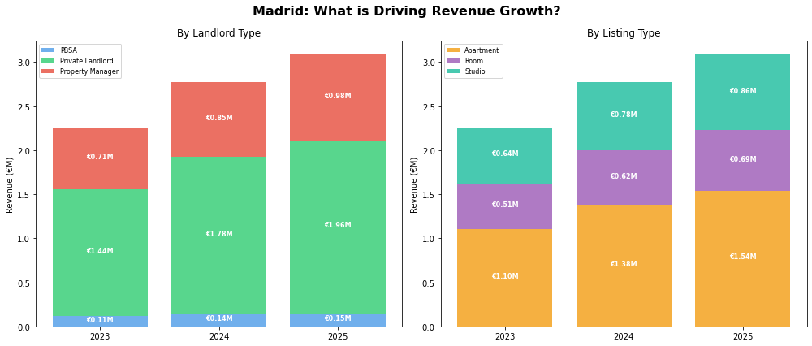

```python
fig, axes = plt.subplots(1, 2, figsize=(14, 6))
fig.suptitle('Madrid: What is Driving Revenue Growth?', fontsize=16, fontweight='bold')

years_list = [2023, 2024, 2025]
colors_landlord = {'PBSA': '#4C9BE8', 'Private Landlord': '#2ECC71', 'Property Manager': '#E74C3C'}
colors_listing = {'Apartment': '#F39C12', 'Room': '#9B59B6', 'Studio': '#1ABC9C'}

# Chart 1: Revenue by landlord type
bottom = np.zeros(3)
for landlord, color in colors_landlord.items():
    values = [landlord_revenue[(landlord_revenue['year']==y) &
              (landlord_revenue['landlord_type']==landlord)]['total_revenue'].values[0]/1000000
              for y in years_list]
    axes[0].bar(range(3), values, bottom=bottom, label=landlord, color=color, alpha=0.8)
    for i, (val, bot) in enumerate(zip(values, bottom)):
        if val > 0.05:
            axes[0].text(i, bot + val/2, f'€{val:.2f}M',
                        ha='center', fontsize=8, fontweight='bold', color='white')
    bottom += np.array(values)

axes[0].set_xticks(range(3))
axes[0].set_xticklabels(['2023', '2024', '2025'])
axes[0].set_title('By Landlord Type')
axes[0].set_ylabel('Revenue (€M)')
axes[0].legend(loc='upper left', fontsize=8)

# Chart 2: Revenue by listing type
bottom = np.zeros(3)
for listing, color in colors_listing.items():
    values = [listing_revenue[(listing_revenue['year']==y) &
              (listing_revenue['listing_type']==listing)]['total_revenue'].values[0]/1000000
              for y in years_list]
    axes[1].bar(range(3), values, bottom=bottom, label=listing, color=color, alpha=0.8)
    for i, (val, bot) in enumerate(zip(values, bottom)):
        if val > 0.05:
            axes[1].text(i, bot + val/2, f'€{val:.2f}M',
                        ha='center', fontsize=8, fontweight='bold', color='white')
    bottom += np.array(values)

axes[1].set_xticks(range(3))
axes[1].set_xticklabels(['2023', '2024', '2025'])
axes[1].set_title('By Listing Type')
axes[1].set_ylabel('Revenue (€M)')
axes[1].legend(loc='upper left', fontsize=8)

plt.tight_layout()
plt.savefig('slide2_segments.png', dpi=150, bbox_inches='tight')
plt.show()
```

Despite booking growth of only **+17%**, revenue grew significantly faster at **+37%** between 2023 and 2025. This means HousingAnywhere Madrid is earning more per booking (revenue per booking increased from €203 in 2023 to €238 in 2025).

**What is driving this?**

By landlord type: All three segments are growing at similar rates, with Property Managers showing the strongest growth at +37.8%, slightly ahead of Private Landlords (+36.5%) and PBSA (+30.4%). Private Landlords remain the dominant revenue source, contributing approximately 63% of total revenue.

By listing type: Apartments are the fastest growing segment at +39.3%, outpacing Rooms (+34.5%) and Studios (+33.6%). Apartments also command the highest average rent, which explains the increase in revenue per booking over time.

**Key insight:** Madrid's revenue growth is being driven by a shift toward higher-value listings particularly apartments, and growing Property Manager supply. Even as booking volume growth slows, the platform is capturing more value per transaction.

```python
# Monthly revenue across all years
df['month'] = df['month_booking'].dt.month
df['month_name'] = df['month_booking'].dt.strftime('%b')

seasonality = df.groupby(['year', 'month', 'month_name']).agg(
    total_revenue=('revenue_eur', 'sum'),
    total_bookings=('bookings', 'sum'),
    total_visitors=('visitors', 'sum')
).reset_index().sort_values(['year', 'month'])

# Average by month across all years
avg_seasonality = df.groupby(['month', 'month_name']).agg(
    avg_revenue=('revenue_eur', 'mean'),
    avg_bookings=('bookings', 'mean'),
    avg_visitors=('visitors', 'mean')
).reset_index().sort_values('month')

print(avg_seasonality)
```

```
    month month_name   avg_revenue  avg_bookings  avg_visitors
0       1        Jan  29574.296296    138.370370   6504.037037
1       2        Feb  32430.666667    145.851852   7158.481481
2       3        Mar  28802.962963    132.851852   6453.629630
3       4        Apr  27490.666667    126.555556   6224.296296
4       5        May  28320.777778    127.888889   6691.629630
5       6        Jun  16534.037037     75.296296   7603.185185
6       7        Jul  13357.703704     61.703704   8124.370370
7       8        Aug  14894.370370     69.111111   8645.925926
8       9        Sep  31124.740741    134.148148   8680.370370
9      10        Oct  27973.185185    124.037037   6886.703704
10     11        Nov  26717.962963    115.888889   6427.740741
11     12        Dec  23555.851852    104.777778   5736.592593
```

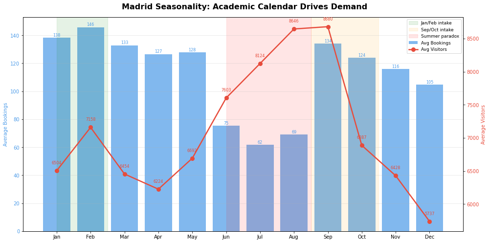

```python
fig, ax1 = plt.subplots(figsize=(14, 7))
fig.suptitle('Madrid Seasonality: Academic Calendar Drives Demand',
             fontsize=16, fontweight='bold')

months = avg_seasonality['month_name']
x = np.arange(len(months))

bars = ax1.bar(x, avg_seasonality['avg_bookings'], color='#4C9BE8',
               alpha=0.7, label='Avg Bookings')
ax1.set_ylabel('Average Bookings', color='#4C9BE8')
ax1.set_xticks(x)
ax1.set_xticklabels(months)
ax1.tick_params(axis='y', labelcolor='#4C9BE8')

for bar, val in zip(bars, avg_seasonality['avg_bookings']):
    ax1.text(bar.get_x() + bar.get_width()/2, bar.get_height() + 1,
             f'{val:.0f}', ha='center', fontsize=8, color='#4C9BE8')

ax2 = ax1.twinx()
ax2.plot(x, avg_seasonality['avg_visitors'], marker='o', linewidth=2.5,
         markersize=8, color='#E74C3C', label='Avg Visitors')
ax2.set_ylabel('Average Visitors', color='#E74C3C')
ax2.tick_params(axis='y', labelcolor='#E74C3C')

for i, val in enumerate(avg_seasonality['avg_visitors']):
    ax2.text(i, val + 100, f'{val:.0f}', ha='center',
             fontsize=8, color='#E74C3C')

ax1.axvspan(0, 1.5, alpha=0.1, color='green', label='Jan/Feb intake')
ax1.axvspan(7.5, 9.5, alpha=0.1, color='orange', label='Sep/Oct intake')
ax1.axvspan(5, 7.5, alpha=0.1, color='red', label='Summer paradox')

lines1, labels1 = ax1.get_legend_handles_labels()
lines2, labels2 = ax2.get_legend_handles_labels()
ax1.legend(lines1 + lines2, labels1 + labels2, loc='upper right', fontsize=9)

ax1.grid(axis='y', alpha=0.3)

plt.tight_layout()
plt.savefig('slide3_seasonality.png', dpi=150, bbox_inches='tight')
plt.show()
```

**January/February intake** The start of the spring semester drives a strong booking spike. Average bookings reach 138-146 per month during this period.

This suggests summer traffic is driven by early browsers and tourists rather than tenants with immediate booking intent. Conversion during this period is significantly below the annual average.

**Key insight:** HousingAnywhere Madrid should align landlord acquisition campaigns and marketing investment with academic calendar peaks particularly July/August when future students begin researching, and September when they commit to booking.

```python
# Supply vs Demand exploration
supply_demand = df.groupby(['year', 'month']).agg(
    total_available_listings=('available_listings', 'sum'),
    total_created_listings=('created_listings', 'sum'),
    total_applicants=('applicants', 'sum'),
    total_bookings=('bookings', 'sum')
).reset_index().sort_values(['year', 'month'])

# Annual summary
annual_supply = df.groupby('year').agg(
    total_available_listings=('available_listings', 'sum'),
    total_created_listings=('created_listings', 'sum'),
    total_applicants=('applicants', 'sum'),
    total_bookings=('bookings', 'sum')
).reset_index()

# Supply utilisation = bookings / available listings
annual_supply['utilisation_rate'] = annual_supply['total_bookings'] / annual_supply['total_available_listings'] * 100

# Demand pressure = applicants / available listings
annual_supply['demand_pressure'] = annual_supply['total_applicants'] / annual_supply['total_available_listings']

print(annual_supply)
```

```
   year  total_available_listings  total_created_listings  total_applicants  \
0  2023                     25934                    2763             47375
1  2024                     35837                    5697             55903
2  2025                     45518                    5116             60953

   total_bookings  utilisation_rate  demand_pressure
0           11085         42.743117         1.826753
1           12570         35.075481         1.559924
2           12970         28.494222         1.339097
```

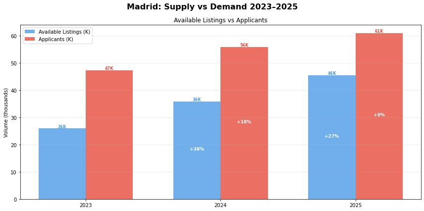

```python
fig, ax = plt.subplots(figsize=(12, 6))
fig.suptitle('Madrid: Supply vs Demand 2023–2025', fontsize=16, fontweight='bold')

years_list = ['2023', '2024', '2025']
x = np.arange(len(years_list))
width = 0.35

# Available listings vs Applicants
bars1 = ax.bar(x - width/2, annual_supply['total_available_listings']/1000,
               width, label='Available Listings (K)', color='#4C9BE8', alpha=0.8)
bars2 = ax.bar(x + width/2, annual_supply['total_applicants']/1000,
               width, label='Applicants (K)', color='#E74C3C', alpha=0.8)

# Add labels and YoY growth
for i, (bar, val) in enumerate(zip(bars1, annual_supply['total_available_listings']/1000)):
    ax.text(bar.get_x() + bar.get_width()/2, bar.get_height() + 0.3,
            f'{val:.0f}K', ha='center', fontsize=8, fontweight='bold', color='#4C9BE8')
    if i > 0:
        growth = ((annual_supply['total_available_listings'].iloc[i] -
                   annual_supply['total_available_listings'].iloc[i-1]) /
                   annual_supply['total_available_listings'].iloc[i-1]) * 100
        ax.text(bar.get_x() + bar.get_width()/2, bar.get_height()/2,
                f'+{growth:.0f}%', ha='center', fontsize=9,
                fontweight='bold', color='white')

for i, (bar, val) in enumerate(zip(bars2, annual_supply['total_applicants']/1000)):
    ax.text(bar.get_x() + bar.get_width()/2, bar.get_height() + 0.3,
            f'{val:.0f}K', ha='center', fontsize=8, fontweight='bold', color='#E74C3C')
    if i > 0:
        growth = ((annual_supply['total_applicants'].iloc[i] -
                   annual_supply['total_applicants'].iloc[i-1]) /
                   annual_supply['total_applicants'].iloc[i-1]) * 100
        ax.text(bar.get_x() + bar.get_width()/2, bar.get_height()/2,
                f'+{growth:.0f}%', ha='center', fontsize=9,
                fontweight='bold', color='white')

ax.set_xticks(x)
ax.set_xticklabels(years_list)
ax.set_title('Available Listings vs Applicants')
ax.set_ylabel('Volume (thousands)')
ax.legend()
ax.grid(axis='y', alpha=0.3)

plt.tight_layout()
plt.savefig('slide4_supply.png', dpi=150, bbox_inches='tight')
plt.show()
```

Madrid's supply has grown significantly between 2023 and 2025:

- Available listings increased by **+75%** (25,934 → 45,518)
- New listings created grew from 2,763 in 2023 to 5,116 in 2025

However, demand growth is not keeping pace with supply expansion:

- Applicants grew only **+29%** (47,375 → 60,953)
- Listing utilisation rate declined from **42.7%** in 2023 to **28.5%** in 2025

**What this means:** In 2023, roughly 43 out of every 100 listings received a booking. By 2025, that number dropped to only 28 out of every 100.

A growing number of listings are sitting empty and not converting into bookings. This suggests that while HousingAnywhere is successfully attracting more landlords to the platform, the quality or positioning of new listings may not be meeting tenant expectations.

**Key insight:** The challenge in Madrid is no longer supply shortage, it is supply quality and matching efficiency. New listings need better onboarding, pricing guidance, and optimisation to convert applicants into bookings at the same rate as established listings.

```python
# Average rent trends over time
rent_trends = df.groupby(['year', 'month']).agg(
    avg_rent=('avg_rent_eur', 'mean')
).reset_index()

# Annual average rent
annual_rent = df.groupby('year').agg(
    avg_rent=('avg_rent_eur', 'mean')
).reset_index()

# Rent by listing type
rent_by_listing = df.groupby(['year', 'listing_type']).agg(
    avg_rent=('avg_rent_eur', 'mean')
).reset_index()

# Rent by landlord type
rent_by_landlord = df.groupby(['year', 'landlord_type']).agg(
    avg_rent=('avg_rent_eur', 'mean')
).reset_index()

print("=== ANNUAL AVERAGE RENT ===")
print(annual_rent)
print("\n=== RENT BY LISTING TYPE ===")
print(rent_by_listing)
print("\n=== RENT BY LANDLORD TYPE ===")
print(rent_by_landlord)
```

```
=== ANNUAL AVERAGE RENT ===
   year     avg_rent
0  2023  1098.851852
1  2024  1216.101852
2  2025  1327.453704

=== RENT BY LISTING TYPE ===
   year listing_type     avg_rent
0  2023    Apartment  1686.611111
1  2023         Room   659.583333
2  2023       Studio   950.361111
3  2024    Apartment  1867.805556
4  2024         Room   732.111111
5  2024       Studio  1048.388889
6  2025    Apartment  2042.666667
7  2025         Room   793.638889
8  2025       Studio  1146.055556

=== RENT BY LANDLORD TYPE ===
   year     landlord_type     avg_rent
0  2023              PBSA  1102.361111
1  2023  Private Landlord  1102.027778
2  2023  Property Manager  1092.166667
3  2024              PBSA  1219.361111
4  2024  Private Landlord  1216.916667
5  2024  Property Manager  1212.027778
6  2025              PBSA  1330.138889
7  2025  Private Landlord  1329.694444
8  2025  Property Manager  1322.527778
```

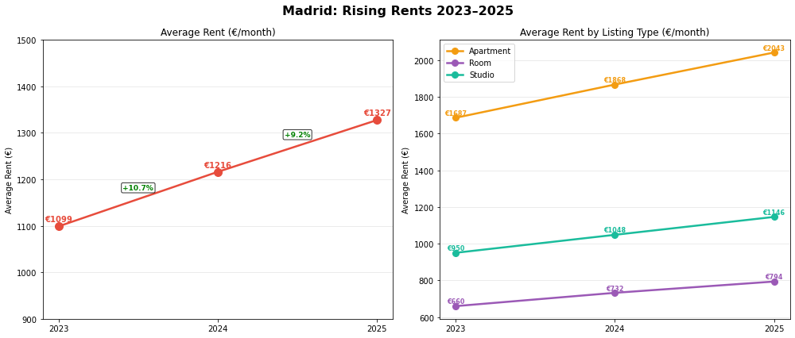

```python
fig, axes = plt.subplots(1, 2, figsize=(14, 6))
fig.suptitle('Madrid: Rising Rents 2023–2025', fontsize=16, fontweight='bold')

years_list = ['2023', '2024', '2025']
x = np.arange(len(years_list))
width = 0.25

# Chart 1: Overall average rent trend
axes[0].plot(years_list, annual_rent['avg_rent'], marker='o',
             linewidth=2.5, markersize=10, color='#E74C3C')
axes[0].set_title('Average Rent (€/month)')
axes[0].set_ylabel('Average Rent (€)')
axes[0].set_ylim(900, 1500)
axes[0].grid(axis='y', alpha=0.3)

for i, val in enumerate(annual_rent['avg_rent']):
    axes[0].text(i, val + 10, f'€{val:.0f}', ha='center',
                fontsize=10, fontweight='bold', color='#E74C3C')
    if i > 0:
        growth = ((annual_rent['avg_rent'].iloc[i] - annual_rent['avg_rent'].iloc[i-1]) /
                   annual_rent['avg_rent'].iloc[i-1]) * 100
        axes[0].text(i - 0.5, (annual_rent['avg_rent'].iloc[i] +
                    annual_rent['avg_rent'].iloc[i-1])/2 + 20,
                    f'+{growth:.1f}%', ha='center', fontsize=9,
                    fontweight='bold', color='green',
                    bbox=dict(boxstyle='round,pad=0.2', facecolor='white', alpha=0.8))

# Chart 2: Rent by listing type
colors_listing = {'Apartment': '#F39C12', 'Room': '#9B59B6', 'Studio': '#1ABC9C'}

for i, (listing, color) in enumerate(colors_listing.items()):
    values = rent_by_listing[rent_by_listing['listing_type']==listing]['avg_rent']
    axes[1].plot(years_list, values, marker='o', linewidth=2.5,
                markersize=8, color=color, label=listing)
    for j, val in enumerate(values):
        axes[1].text(j, val + 15, f'€{val:.0f}', ha='center',
                    fontsize=8, fontweight='bold', color=color)

axes[1].set_title('Average Rent by Listing Type (€/month)')
axes[1].set_ylabel('Average Rent (€)')
axes[1].grid(axis='y', alpha=0.3)
axes[1].legend()

plt.tight_layout()
plt.savefig('slide5_rent.png', dpi=150, bbox_inches='tight')
plt.show()
```

Average rents in Madrid have increased significantly between 2023 and 2025:

- Overall average rent grew from **€1,099** to **€1,327**, an increase of **+20.8%** in just 2 years
- The increase is consistent across all listing types and landlord types

**Rent growth by listing type:**

- Apartments: €1,687 → €2,043 (**+21%**)
- Studios: €950 → €1,146 (**+21%**)
- Rooms: €660 → €794 (**+20%**)

**The connection to supply and utilisation:** When read alongside previous chart, a clear picture emerges. Supply grew **+75%** and rents grew **+21%** but applicants only grew **+29%** and utilisation dropped from **42.7%** to **28.5%**.

Rising rents are likely contributing to the declining utilisation rate. Tenants are browsing and applying but not completing bookings because listings are becoming increasingly unaffordable.

This is consistent with HousingAnywhere's own research, which identifies high rental prices and lack of affordable properties as the most common barriers for young tenants in Europe.

**Key insight:** Madrid faces a growing affordability gap. More listings are available than ever before, but rising rents are pricing out the core tenant audience, the international students and young professionals with limited budgets.

Based on the analysis of Madrid's performance between 2023 and 2025, three priority recommendations emerge:

**Recommendation 1 - Improve Funnel Conversion Through Listing Quality**

**What:** Introduce a listing quality score combining completeness, photos, response time, and pricing competitiveness. Prioritise high-scoring listings in search results and provide landlords with actionable optimisation tips.

**Why:** Visitors grew +58% but bookings only grew +17%. A growing proportion of applicants are not converting into bookings. With utilisation dropping from 42.7% to 28.5%, many listings are clearly not meeting tenant expectations.

**Expected impact:** Even a 5% improvement in applicant-to-booking conversion would generate approximately 3,000 additional bookings annually.

**Recommendation 2 - Align Acquisition and Marketing with Academic Calendar**

**What:** Concentrate landlord acquisition campaigns in May-July, ahead of the September peak. Launch tenant re-engagement campaigns in June-August to convert summer browsers into autumn bookings.

**Expected impact:** Capturing even 10% of summer browsers as autumn bookings could add 800+ bookings during the peak September period.

**Recommendation 3 - Address the Affordability Gap**

**What:** Introduce a budget-friendly listing category or affordability filter for tenants. Incentivise landlords to offer competitive pricing through featured placement or reduced commission rates for listings priced below market average.

**Why:** Average rents rose +20.8% in two years (€1,099 → €1,327) while the core tenant audience (international students and young professionals) has limited budgets. This affordability gap is directly contributing to declining utilisation and conversion rates.

**Expected impact:** Reducing price-driven drop-off in the application funnel could improve conversion rates and reactivate the growing pool of unlisted supply.